# Advanced Machine Learning - Classification Midterm Project

This notebook reports my findings and implementation regarding sentiment classification on a movie review from the IMDB dataset

- **Student: Georgiy Farina (georgiy.farina@student.supsi.ch)**
- **Teacher: Loris Cannelli (loris.cannelli@supsi.ch)**
- **Start Date: 26.12.2023**
- **End Date: 06.01.2024**

## Task 0

Importing necessary libraries for data loading, models creation/training/evaluation and visualizing various plots

```python
import matplotlib.pyplot as plt
from sklearn.metrics import roc_curve, auc
import os
from tensorflow import keras
from keras.datasets import imdb
from keras.models import Sequential, load_model
from keras.utils import pad_sequences
from keras.layers import Flatten, Embedding, Dense, Conv1D, SimpleRNN, LSTM, MaxPooling1D, BatchNormalization, Dropout
```

## Task 1: Load the IMDB dataset and create a feedforward network in order to predict the sentiment score

This is the loading part of the data. In the cell below I loaded the data and also specified some features that will need to be used later on

```python
padding_length = 500
num_words = 10000
embedding_features = 100
(X_train, y_train), (X_test, y_test) = imdb.load_data(num_words=num_words)
```

```python
word_index = keras.datasets.imdb.get_word_index()
```

```python
print(X_train.shape, y_train.shape)
X_train[0]
```

```
(25000,) (25000,)
```

[output not shown]

[output cut: 163 more lines]

[output not shown]

```python
y_train
```

```
array([1, 0, 0, ..., 0, 1, 0], dtype=int64)
```

```python
word_index['movie'] # the value of the word 'movie' will be its occurence in the whole dataset
```

```
17
```

To give an interpretation of the data, the word indexing of the dataset can be imported and used to decode the review of a movie

```python
start_char = 1
oov_char = 2
index_from = 3
inverted_word_index = dict(
    (i + index_from, word) for (word, i) in word_index.items()
)
```

```python
inverted_word_index[start_char] = "[START]"
inverted_word_index[oov_char] = "[OOV]"
decoded_sequence = " ".join(inverted_word_index[i] for i in X_train[0])
decoded_sequence
```

```
"[START] this film was just brilliant casting location scenery story direction everyone's really suited the part they played and you could just imagine being there robert [OOV] is an amazing actor and now the same being director [OOV] father came from the same scottish island as myself so i loved th…
```

As suggested by the professor, i padded the X splits filling them with zeros so that all the entries would be of same length being 500. Records longer than 500 will be truncated, whereas reviews shorter than 500 will be filled up with 0s with the necessary amount to get to 500. Now the shape of the data is precisely 25000 reviews long 500 words represented by indexes of their occurence frequency

```python
X_train = pad_sequences(X_train, maxlen=padding_length, padding='post')
X_test = pad_sequences(X_test, maxlen=padding_length, padding='post')
```

```python
print(X_train.shape, y_train.shape)
X_train[0]
```

```
(25000, 500) (25000,)
```

```
array([   1,   14,   22,   16,   43,  530,  973, 1622, 1385,   65,  458,
       4468,   66, 3941,    4,  173,   36,  256,    5,   25,  100,   43,
        838,  112,   50,  670,    2,    9,   35,  480,  284,    5,  150,
          4,  172,  112,  167,    2,  336,  385,   39,    4,  172, 4536,
       1111,   17,  546,   38,   13,  447,    4,  192,   50,   16,    6,
        147, 2025,   19,   14,   22,    4, 1920, 4613,  469,    4,   22,
         71,   87,   12,   16,   43,  530,   38,   76,   15,   13, 1247,
          4,   22,   17,  515,   17,   12,   16,  626,   18,    2,    5,
         62,  386,   12,    8,  316,    8,  106,    5,    4, 2223, 5244,
         16,  480,   66, 3785,   33,    4,  130,   12,   16,   38,  619,
          5,   25,  124,   51,   36,  135,   48,   25, 1415,   33,    6,
         22,   12,  215,   28,   77,   52,    5,   14,  407,   16,   82,
          2,    8,    4,  107,  117, 5952,   15,  256,    4,    2,    7,
       3766,    5,  723,   36,   71,   43,  530,  476,   26,  400,  317,
         46,    7,    4,    2, 1029,   13,  104,   88,    4,  381,   15,
```

[output cut: 31 more lines]

The function below is designed to verify whether the model passed as parameters exists under the given file name and, if it exists, the model is simply loaded, otherwise it is retrained from scratch. The batch size can also be specified alongside the number of epochs

```python
def load_or_fit(model, model_file_name, batch_size = 64, epochs = 5):
    model_exists = os.path.exists(model_file_name)
    model_history = None
    if model_exists:
        model = load_model(model_file_name)
    else:
        model_history = model.fit(
            X_train,
            y_train,
            batch_size=batch_size,
            epochs=epochs,
            validation_data=(X_test, y_test)
        )
        model.save(model_file_name)
    return model, model_history
```

Here a simple model is trained that has the first flattening layer, and 3 dense ones where the last one is the sigmoid one predicting the output

```python
simple_model = Sequential()
simple_model.add(Flatten())
simple_model.add(Dense(256, activation='relu'))
simple_model.add(Dense(64, activation='relu'))
simple_model.add(Dense(1, activation='sigmoid'))
simple_model.compile(optimizer='adam', loss='binary_crossentropy', metrics=['accuracy'])
```

```python
simple_model, history_simple = load_or_fit(simple_model, 'simple_model_10.h5')
```

After having trained the simple model, it is obvious from the accuracy and loss parameters that it is not better than a random guess. It starts off with a very high loss of approximately 40 which suggests a poor random choice of weights.  
The accuracy gets in a plateau of 0.5 accuracy in both training and validation, suggesting that the model is not able to learn anything with the proposed structure

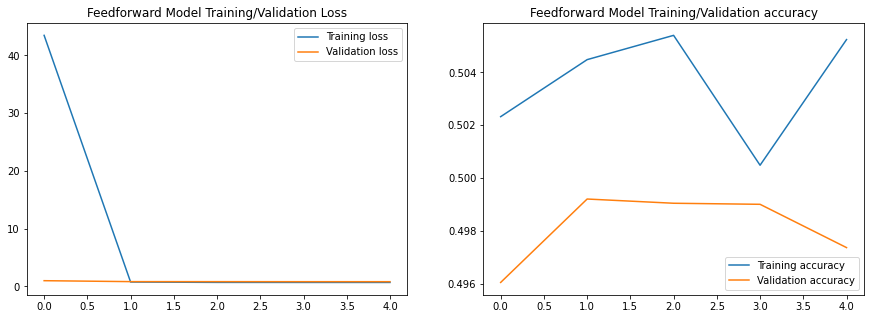

```python
results_simple_model = simple_model.evaluate(X_test, y_test)

if history_simple is not None:
    fig, ax = plt.subplots(ncols=2, figsize=(15, 5))
    ax[0].plot(history_simple.history['loss'], label='Training loss')
    ax[0].plot(history_simple.history['val_loss'], label='Validation loss')

    ax[0].set_title('Feedforward Model Training/Validation Loss')
    ax[0].legend()

    ax[1].plot(history_simple.history['accuracy'], label='Training accuracy')
    ax[1].plot(history_simple.history['val_accuracy'], label='Validation accuracy')

    ax[1].set_title('Feedforward Model Training/Validation accuracy')
    ax[1].legend()
```

## Task 2: Transform your input sentences into a lower dimensional space using embeddings and use these embeddings as input for your previous network

```python
embeddings_model = Sequential()
embeddings_model.add(Embedding(input_dim=num_words, output_dim=embedding_features, input_length=padding_length))
embeddings_model.add(Flatten())
embeddings_model.add(Dense(256, activation='relu'))
embeddings_model.add(Dense(64, activation='relu'))
embeddings_model.add(Dense(1, activation='sigmoid'))
embeddings_model.compile(optimizer='adam', loss='binary_crossentropy', metrics=['accuracy'])
```

```python
embeddings_model, history_embeddings = load_or_fit(embeddings_model, 'embedding_model.h5', epochs=5)
```

There is a lot of improvement, but maybe also too much, since from the second epoch the training accuracy is very close to 1, whereas the validation one hits a plateau around 0.85

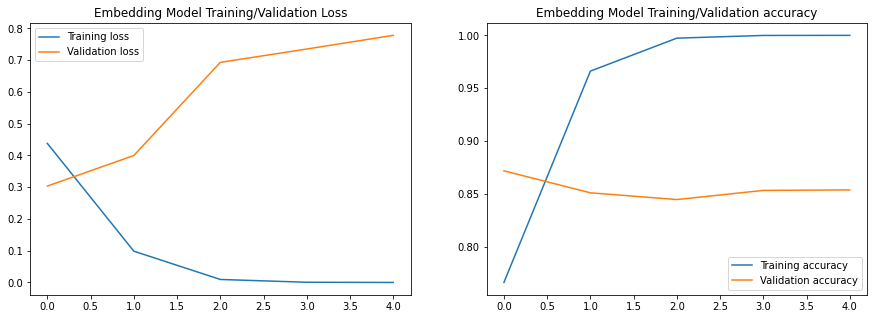

```python
results_embeddings = embeddings_model.evaluate(X_test, y_test)

if history_embeddings is not None:
    fig, ax = plt.subplots(ncols=2, figsize=(15, 5))
    ax[0].plot(history_embeddings.history['loss'], label='Training loss')
    ax[0].plot(history_embeddings.history['val_loss'], label='Validation loss')

    ax[0].set_title('Embedding Model Training/Validation Loss')
    ax[0].legend()

    ax[1].plot(history_embeddings.history['accuracy'], label='Training accuracy')
    ax[1].plot(history_embeddings.history['val_accuracy'], label='Validation accuracy')

    ax[1].set_title('Embedding Model Training/Validation accuracy')
    ax[1].legend()
```

## Task 3: Text can be thought of as 1-dimensional sequence (a single, long vector) and we can apply 1D Convolutions over a set of word embeddings. Add a Conv1D layer before the dense part of your previous network and train the new model.

The current combination of layers now also includes 1D convolution before the flattening

```python
# Embedding + convolution model
embeddings_conv_model = Sequential()
embeddings_conv_model.add(Embedding(input_dim=num_words, output_dim=embedding_features, input_length=padding_length))
embeddings_conv_model.add(Conv1D(32, 5, activation='relu'))
embeddings_conv_model.add(Flatten())
embeddings_conv_model.add(Dense(256, activation='relu'))
embeddings_conv_model.add(Dense(64, activation='relu'))
embeddings_conv_model.add(Dense(1, activation='sigmoid'))
embeddings_conv_model.compile(optimizer='adam', loss='binary_crossentropy', metrics=['accuracy'])
```

```python
embeddings_conv_model, history_embeddings_conv = load_or_fit(embeddings_conv_model, 'embedding_conv_20_model.h5', batch_size=128, epochs=20)
```

The results now are a little better, meaning that also the validation score has improved slightly (instead of 0.85, now the plateau is at 0.87), but the problem is still about the training accuracy, which still tends to be practically 1.

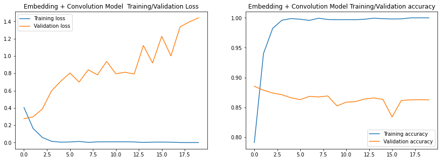

```python
results_embeddings_conv = embeddings_conv_model.evaluate(X_test, y_test)

if history_embeddings_conv is not None:

    fig, ax = plt.subplots(ncols=2, figsize=(15, 5))
    ax[0].plot(history_embeddings_conv.history['loss'], label='Training loss')
    ax[0].plot(history_embeddings_conv.history['val_loss'], label='Validation loss')

    ax[0].set_title('Embedding + Convolution Model  Training/Validation Loss')
    ax[0].legend()

    ax[1].plot(history_embeddings_conv.history['accuracy'], label='Training accuracy')
    ax[1].plot(history_embeddings_conv.history['val_accuracy'], label='Validation accuracy')

    ax[1].set_title('Embedding + Convolution Model Training/Validation accuracy')
    ax[1].legend()
```

## Task 4: Instead of Convolution+Dense, let us try to use Recurrent Networks. Keep the embedded inputs and test the performances of three simple networks: i) SimpleRNN; ii) LSTM; iii) Conv1D+LSTM (just one recurrent layer should be sufficient in all of these networks).

Below the 3 recurrent networks can be found. The training, even though the suggested number of epochs by the teacher was 5, I tried to improve the quality by training the models for 20 epochs.

```python
simple_rnn_model = Sequential()
simple_rnn_model.add(Embedding(input_dim=num_words, output_dim=embedding_features, input_length=padding_length))
simple_rnn_model.add(SimpleRNN(64))
simple_rnn_model.add(Dense(1, activation='sigmoid'))
simple_rnn_model.compile(optimizer='adam', loss='binary_crossentropy', metrics=['accuracy'])
```

```python
simple_rnn_model, history_rnn = load_or_fit(simple_rnn_model, 'simple_rnn_20_model.h5', batch_size=128, epochs=20)
```

```python
lstm_model = Sequential()
lstm_model.add(Embedding(input_dim=num_words, output_dim=embedding_features, input_length=padding_length))
lstm_model.add(LSTM(64))
lstm_model.add(Dense(1, activation='sigmoid'))
lstm_model.compile(optimizer='adam', loss='binary_crossentropy', metrics=['accuracy'])
```

```python
lstm_model, history_lstm = load_or_fit(lstm_model, 'lstm_20_model.h5', batch_size=128, epochs=20)
```

```python
conv_lstm_model = Sequential()
conv_lstm_model.add(Embedding(input_dim=num_words, output_dim=embedding_features, input_length=padding_length))
conv_lstm_model.add(Conv1D(32, 5, activation='relu'))
conv_lstm_model.add(MaxPooling1D())
conv_lstm_model.add(LSTM(64))
conv_lstm_model.add(Dense(1, activation='sigmoid'))
conv_lstm_model.compile(optimizer='adam', loss='binary_crossentropy', metrics=['accuracy'])
```

```python
conv_lstm_model, history_conv_lstm = load_or_fit(conv_lstm_model, 'lstm_conv_20_model.h5', batch_size=128, epochs=20)
```

From the plots below the following can be concluded:

- SimpleRNN: performs as would a random guess. Even after 20 epochs it plateaus at ca. 0.55 on the training and 0.5 at the validation
- LSTM: same kind of performance as the SimpleRNN one
- LSTM + Conv1D: the best model out of the 3. With a difficult initial training phase where there are a lot of positive and negative spikes, it manages to seemingly stabilize itself after the 12th epoch, where both training and validation start to grow. It seems as if the model would overfit if it'd been trained on more epochs.

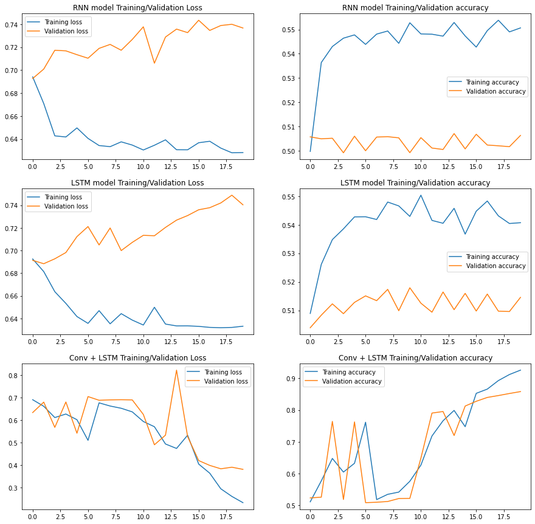

```python
if not (history_rnn is None and history_lstm is None and history_conv_lstm is None):

    labels = ['RNN model', 'LSTM model', 'Conv + LSTM']
    fig, ax = plt.subplots(nrows=3, ncols=2, figsize=(15, 15))
    for i, hist in enumerate([history_rnn, history_lstm, history_conv_lstm]):
        ax[i, 0].plot(hist.history['loss'], label='Training loss')
        ax[i, 0].plot(hist.history['val_loss'], label='Validation loss')

        ax[i, 0].set_title(f'{labels[i]} Training/Validation Loss')
        ax[i, 0].legend()

        ax[i, 1].plot(hist.history['accuracy'], label='Training accuracy')
        ax[i, 1].plot(hist.history['val_accuracy'], label='Validation accuracy')

        ax[i, 1].set_title(f'{labels[i]} Training/Validation accuracy')
        ax[i, 1].legend()
```

## Bonus point: Improve your previous networks testing other ideas that may come to your mind. Is there any improvement?

For the three previous models I tried to change layers and tune some parameters. My main focus was to add BatchNormalization where it could make sense, some Dropout layers and change the number of neurons where it made sense. Below the modified models:

```python
improved_rnn_model = Sequential()
improved_rnn_model.add(Embedding(input_dim=num_words, output_dim=embedding_features, input_length=padding_length))
improved_rnn_model.add(SimpleRNN(64, activation='relu', return_sequences=True))
improved_rnn_model.add(BatchNormalization())
improved_rnn_model.add(Dropout(0.5))
improved_rnn_model.add(Dense(32, activation='relu'))
improved_rnn_model.add(BatchNormalization())
improved_rnn_model.add(SimpleRNN(32))
improved_rnn_model.add(BatchNormalization())
improved_rnn_model.add(Dropout(0.5))
improved_rnn_model.add(Dense(1, activation='sigmoid'))
improved_rnn_model.compile(optimizer='adam', loss='binary_crossentropy', metrics=['accuracy'])
```

```python
improved_rnn_model, history_improved_rnn = load_or_fit(improved_rnn_model, 'improved_20_rnn.h5', batch_size=128, epochs=20)
```

```python
improved_lstm_model = Sequential()
improved_lstm_model.add(Embedding(input_dim=num_words, output_dim=embedding_features, input_length=padding_length))
improved_lstm_model.add(BatchNormalization())
improved_lstm_model.add(LSTM(64, dropout=0.2, recurrent_dropout=0.2))
improved_lstm_model.add(BatchNormalization())
improved_lstm_model.add(Dense(32, activation='relu'))
improved_lstm_model.add(BatchNormalization())
improved_lstm_model.add(Dense(1, activation='sigmoid'))
improved_lstm_model.compile(optimizer='adam', loss='binary_crossentropy', metrics=['accuracy'])
```

```python
improved_lstm_model, history_improved_lstm = load_or_fit(improved_lstm_model, 'improved_lstm.h5', batch_size=128, epochs=20)
```

```python
improved_conv_lstm_model = Sequential()
improved_conv_lstm_model.add(Embedding(input_dim=num_words, output_dim=embedding_features, input_length=padding_length))
improved_conv_lstm_model.add(Conv1D(32, 5, activation='relu'))
improved_conv_lstm_model.add(BatchNormalization())
improved_conv_lstm_model.add(MaxPooling1D())
improved_conv_lstm_model.add(LSTM(64, dropout=0.5, recurrent_dropout=0.5))
improved_conv_lstm_model.add(BatchNormalization())
improved_conv_lstm_model.add(Dense(1, activation='sigmoid'))
improved_conv_lstm_model.compile(optimizer='adam', loss='binary_crossentropy', metrics=['accuracy'])
```

```python
improved_conv_lstm_model, history_improved_conv_lstm = load_or_fit(improved_conv_lstm_model, 'improved_conv_lstm_20.h5', batch_size=128, epochs=20)
```

After having retrained the previous models under new structures, the following are the results:

- SimpleRNN: performance remains almost identical as before. This model is definitely not appropriate for this task
- LSTM: a significant improvement can be seen in this model, where the training got to 1 as score and the validation stays approximately at 0.86/0.87. There could be done other improvements, but from what it seems, the best models in this context are able to get to this score and not more.
- LSTM + Conv1D: Similarly to the previous one, without the Convolution layer, it learns from the data up to a certain point, from which it stays on a plateau, achieving very similar results as the LSTM on its own

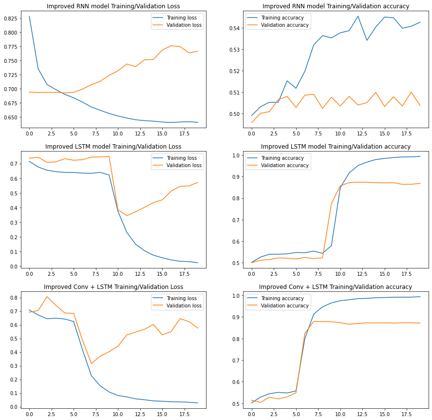

```python
if not (history_improved_rnn is None and history_improved_lstm is None and history_improved_conv_lstm is None):
    labels = ['Improved RNN model', 'Improved LSTM model', 'Improved Conv + LSTM']
    fig, ax = plt.subplots(nrows=3, ncols=2, figsize=(15, 15))
    for i, hist in enumerate([history_improved_rnn, history_improved_lstm, history_improved_conv_lstm]):
        ax[i, 0].plot(hist.history['loss'], label='Training loss')
        ax[i, 0].plot(hist.history['val_loss'], label='Validation loss')

        ax[i, 0].set_title(f'{labels[i]} Training/Validation Loss')
        ax[i, 0].legend()

        ax[i, 1].plot(hist.history['accuracy'], label='Training accuracy')
        ax[i, 1].plot(hist.history['val_accuracy'], label='Validation accuracy')

        ax[i, 1].set_title(f'{labels[i]} Training/Validation accuracy')
        ax[i, 1].legend()
```

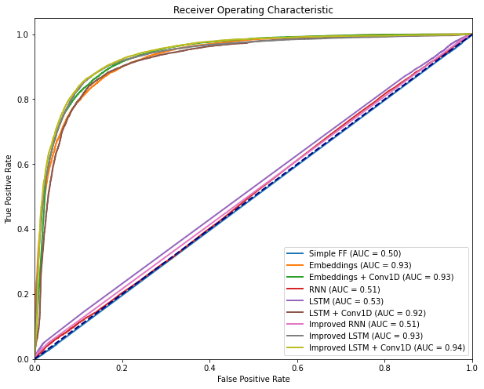

```python
models = {
    "Simple FF": simple_model,
    "Embeddings": embeddings_model,
    'Embeddings + Conv1D': embeddings_conv_model,
    'RNN': simple_rnn_model,
    'LSTM': lstm_model,
    'LSTM + Conv1D': conv_lstm_model,
    'Improved RNN': improved_rnn_model,
    'Improved LSTM': improved_lstm_model,
    'Improved LSTM + Conv1D': improved_conv_lstm_model
}
plt.figure(figsize=(10, 8))

for name, model in models.items():
    y_pred = model.predict(X_test)[:, 0]

    fpr, tpr, _ = roc_curve(y_test, y_pred)
    roc_auc = auc(fpr, tpr)

    plt.plot(fpr, tpr, lw=2, label=f'{name} (AUC = {roc_auc:.2f})')

plt.plot([0, 1], [0, 1], color='navy', lw=2, linestyle='--')
plt.xlim([0.0, 1.0])
plt.ylim([0.0, 1.05])
plt.xlabel('False Positive Rate')
plt.ylabel('True Positive Rate')
plt.title('Receiver Operating Characteristic')
plt.legend(loc="lower right")
plt.show()
```

## Final results and considerations

From the model fitting above we got some results, where some are better and others are worse. Let's take the best performing model (Improved LSTM + Conv1D) and try to use it to predict some artificially created reviews, to compare how well and in which situations it's able to predict the sentiment.

```python
def parse_text(text):
    return [word_index[word] for word in text.lower().split()]
```

```python
def evaluate_review(model, review):
    parsed_review = pad_sequences([parse_text(review)], maxlen=500, padding='post')
    # parsed_review = parse_text(review)
    prediction = model.predict(parsed_review, verbose=0)
    return prediction
```

```python
good_text = 'This movie is of great quality and very good'
good_result = evaluate_review(improved_conv_lstm_model, good_text)

bad_text = 'This movie is so bad i wanted to vomit from how bad it was'
bad_result = evaluate_review(improved_conv_lstm_model, bad_text)

print(f"100% = Good / 0% = Bad\n")
print(f'\"{good_text}\": {round(good_result[0][0] * 100, 2)}%')
print(f'\"{bad_text}\": {round(bad_result[0][0] * 100, 2)}%')
```

```
100% = Good / 0% = Bad

"This movie is of great quality and very good": 43.84%
"This movie is so bad i wanted to vomit from how bad it was": 0.58%
```

- The testing string has to be long enough to be correctly evaluated, otherwise the model can mess up

```python
bug_test = 'bad'
bug_result = evaluate_review(improved_conv_lstm_model, bug_test)

print(f'\"{bug_test}\": {round(bug_result[0][0] * 100, 2)}%')

bug_test = 'perfect'
bug_result = evaluate_review(improved_conv_lstm_model, bug_test)

print(f'\"{bug_test}\": {round(bug_result[0][0] * 100, 2)}%')
```

```
"bad": 63.71%
"perfect": 63.71%
```

- In order not to get a bug when evaluating a review, not all the words can be used since they are not present in the words dictionary loaded from Keras

```python
bug_test = 'i puked watching it'
print(f'Trying to evaluate \"{bug_test}\"...')

try:
    bug_result = evaluate_review(improved_conv_lstm_model, bug_test)
    print(f'\n\t{round(bug_result[0][0] * 100, 2)}%')
except:
    print("\n\tERROR: The word \'puked\' is not in the database of words")
    print('-'*30)

ok_test = 'i loved watching this movie because its very good and wholesome'
print(f'Trying to evaluate \"{ok_test}\"...')

bug_result = evaluate_review(improved_conv_lstm_model, ok_test)
print(f'\n\t{round(bug_result[0][0] * 100, 2)}%')
```

```
Trying to evaluate "i puked watching it"...

	ERROR: The word 'puked' is not in the database of words
------------------------------
Trying to evaluate "i loved watching this movie because its very good and wholesome"...

	99.18%
```